# Proyecto

Rodriguez Nuñez Martin

14/9/2021

```r
library(haven)
library(lavaan)
```

```r
library (semPlot)
```

# 1. Objetivo.

Construir un modelo estructural completo para el siguiente caso:

**Continuidad de empresas familiares**

Se conoce que las empresas familiares tienen una menor continuidad del negocio empresario por conflictos en el seno familiar que requieren de consensos para elaborar un “protocolo familiar”.

Se determinan los siguientes constructos: *Conflicto*, *Proceso P* y *Consen*.

Las variables observadas están en escala Likert de 1 (muy de acuerdo) a 7 (muy en descuerdo).

# 2. Hipotesis.

**H1:** Las variables directamente observables elegidas miden correctamente las variables latentes subyacentes en ellas.

**H2:** El constructo *Proceso P* contribuye a la continuidad de las empresas familiares.

**H3:** El constructo *Consenso* contribuye a la continuidad de las empresas familiares.

**H4:** El constructo *Conflicto* contribuye a la continuidad de las empresas familiares.

# 3. Estimación de modelo SEM en dos etapas.

Primero definimos un modelo de referencia que incluya todas las variables con el fin de comparar los posteriores modelos competidores que se definirán entresacando variables del modelo de referencia y variando supuestos.

Consideramos que las metricas mas importantes para determinar si un modelo es aceptable o no son: * *CFIrobust*  
* *Ratio de Chi-2* * *rmsea* * *srmr*

Para la inclusión de las variables observables se tomarán como un criterio límite de las caras estandarizadas un valor mínimo de *0.7*.

## 3.1. Modelo de Referencia (*fit0*).

Este modelo contempla todas las variables observadas que forman las tres variables latentes.

```r
cfa_fit <-'
  conflicto =~ 1 * C20 + C21 + C22 + C25 + C32 + C34
  procesop =~ 1 * C24 + C38
  concenso =~ 1 * C27 + C28 + C29 + C30

  #Varianza de los Factores
  conflicto~~conflicto
  procesop~~procesop
  concenso~~concenso

  #Varianzas y covarianzas de los errores
  C20~~C20
  C21~~C21
  C22~~C22
  C25~~C25
  C32~~C32
  C34~~C34

  C24~~C24
  C38~~C38

  C27~~C27
  C28~~C28
  C29~~C29
  C30~~C30
'
fit0 <- lavaan(cfa_fit, data=datos, std.lv=TRUE, mimic="eqs", estimator="MLM", verbose=TRUE, warn=TRUE)
a<-summary (fit0, fit.measures=TRUE, standardized=TRUE, rsquare=TRUE)
```

Las métricas de *fit0* fueron:

```
## [1] "CFIrobust= 0.746890026622984"
```

```
## [1] "RATIO= 6.15725956044021"
```

```
## [1] "rmsea= 0.187845526881084"
```

```
## [1] "srmr= 0.402852265294659"
```

Las métricas alcanzadas por *fit0* se encuentran lejanas a las deseadas. Para la metrica *CFIrobust* se busca un valor mayor o igual a *0.95* para ser aceptable. Para el *Ratio de Chi-2* se busca un valor menor o igual a *5* para ser aceptable. Para *rmsea* se busca un valor menor a *0.08*. Por último, para *srmr* se espera un valor menor o igual a *0.1*.

Por lo que podemos decir que el modelo no es aceptable y buscamos un mejor modelo.

## 3.2. Modelo competidor 1 (*fit1*).

Para *fit1* procedemos a borrar la variable *C27* que forma parte del constructo *Consenso* a pesar de ser la segunda que presenta menor carga estandarizada, dado que la de menor carga es la *C24* que forma parte del constructo *Proceso*, el cual se conforma solamente de dos variables observables y dejaría de tener sentido la construcción de una variable latente formada por una sola variable observable.

```r
# Completo luego de ver que dejo y que no y porque
cfa_fit <-'
  conflicto =~ 1 * C20 + C21 + C22 + C25 + C32 + C34
  procesop =~ 1 * C24 + C38
  concenso =~ 1 *  C28 + C29 + C30

  #Varianza de los Factores
  conflicto~~conflicto
  procesop~~procesop
  concenso~~concenso

  #Varianzas y covarianzas de los errores
  C20~~C20
  C21~~C21
  C22~~C22
  C25~~C25
  C32~~C32
  C34~~C34

  C24~~C24
  C38~~C38

  C28~~C28
  C29~~C29
  C30~~C30
'
fit1 <- lavaan(cfa_fit, data=datos, std.lv=TRUE, mimic="eqs", estimator="MLM", verbose=TRUE, warn=TRUE)
a1<-summary (fit1, fit.measures=TRUE, standardized=TRUE, rsquare=TRUE)
```

Las métricas de *fit1* fueron:

```
## [1] "CFIrobust= 0.739596637617296"
```

```
## [1] "RATIO= 7.11814775106285"
```

```
## [1] "rmsea= 0.202031907070682"
```

```
## [1] "srmr= 0.401680281395905"
```

Se observa que las metricas empreoraron respecto a *fit0*. Particularmente las métricas de *Ratio Chi-2* y *rmsea*. Por lo tanto, descartamos el modelo *fit1*.

## 3.3. Modelo competidor 2 (*fit2*).

Para este caso, a pesar del criterio explicado anteriormente, procedemos descartando *C24* y volvemos a introducir *C27*.

```r
# Completo luego de ver que dejo y que no y porque
cfa_fit <-'
  conflicto =~ 1 * C20 + C21 + C22 + C25 + C32 + C34
  procesop =~ 1 *  C38
  concenso =~ 1 * C27 + C28 + C29 + C30

  #Varianza de los Factores
  conflicto~~conflicto
  procesop~~procesop
  concenso~~concenso

  #Varianzas y covarianzas de los errores
  C20~~C20
  C21~~C21
  C22~~C22
  C25~~C25
  C32~~C32
  C34~~C34

  C38~~C38

  C27~~C27
  C28~~C28
  C29~~C29
  C30~~C30
'
fit2 <- lavaan(cfa_fit, data=datos, std.lv=TRUE, mimic="eqs", estimator="MLM", verbose=TRUE, warn=TRUE)
a2<-summary (fit2, fit.measures=TRUE, standardized=TRUE, rsquare=TRUE)
```

Las métricas de *fit2* fueron:

```
## [1] "CFIrobust= 0.815610760629456"
```

```
## [1] "RATIO= 4.99397782109761"
```

```
## [1] "rmsea= 0.165050191225811"
```

```
## [1] "srmr= 0.367428124159961"
```

Vemos que todas las métricas mejoran respeco a los dos modelos anteriores, pero la única métrica aceptable es *Ratio Chi-2* con un valor menor o igual que *5*.

- C38 vuelve a dar mal , vamos a sacarla y ver si es correcto conciderar al constructo *Proceso P*.

## 3.4. Modelo competidor 3 (*fit3*).

Para *fit3*, decidimos eliminar la variable *C38* dado que presentaba la siguiente menor carga estandarizada más baja con un valor de *0.541*. De esta forma, eliminamos por completo el constructo *Proceso P*.

```r
# Completo luego de ver que dejo y que no y porque
cfa_fit <-'
  conflicto =~ 1 * C20 + C21 + C22 + C25 + C32 + C34
  concenso =~ 1 * C27 + C28 + C29 + C30

  #Varianza de los Factores
  conflicto~~conflicto
  concenso~~concenso

  #Varianzas y covarianzas de los errores
  C20~~C20
  C21~~C21
  C22~~C22
  C25~~C25
  C32~~C32
  C34~~C34

  C27~~C27
  C28~~C28
  C29~~C29
  C30~~C30
'
fit3 <- lavaan(cfa_fit, data=datos, std.lv=TRUE, mimic="eqs", estimator="MLM", verbose=TRUE, warn=TRUE)

#Elementos de Salida----
a3<-summary (fit3, fit.measures=TRUE, standardized=TRUE, rsquare=TRUE)
```

Las métricas de *fit3* fueron:

```
## [1] "CFIrobust= 0.892493095370195"
```

```
## [1] "RATIO= 3.85839401365642"
```

```
## [1] "rmsea= 0.136169039699195"
```

```
## [1] "srmr= 0.336473944685224"
```

Se observa que los índices mejoran. Sin embargo, el único índce que cumple es el *Ratio Chic-2*.

## 3.5. Modelo competidor 4 (*fit4*).

Procedemos a sacar la variable C27 para ver si mejora el modelo, ya que es la variable con menor carga estandarizada.

```r
cfa_fit <-'
  conflicto =~ 1 * C20 + C21 + C22 + C25 + C32 + C34
  concenso =~ 1 *  C28 + C29 + C30

  #Varianza de los Factores
  conflicto~~conflicto
  concenso~~concenso

  #Varianzas y covarianzas de los errores
  C20~~C20
  C21~~C21
  C22~~C22
  C25~~C25
  C32~~C32
  C34~~C34

  C28~~C28
  C29~~C29
  C30~~C30
'
fit4 <- lavaan(cfa_fit, data=datos, std.lv=TRUE, mimic="eqs", estimator="MLM", verbose=TRUE, warn=TRUE)

#Elementos de Salida----
a4<-summary (fit4, fit.measures=TRUE, standardized=TRUE, rsquare=TRUE)
```

Las métricas de *fit4* fueron:

```
## [1] "CFIrobust= 0.899853985143206"
```

```
## [1] "RATIO= 4.19095588149552"
```

```
## [1] "rmsea= 0.141325816183805"
```

```
## [1] "srmr= 0.321388218968654"
```

## Correlacion

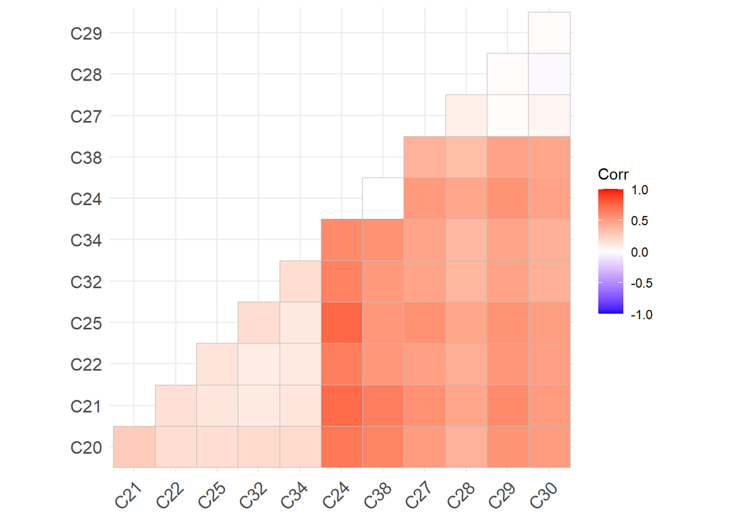

```r
# Analizamos correlacion entre las variables
library(ggplot2)
library(ggcorrplot)
#resid(fit0, "cor")
ggcorrplot(residuals(fit0, type="cor")$cov, type="lower")
```

## 3.6. Modelo competidor 5 (*fit5*).

```r
# Completo luego de ver que dejo y que no y porque
cfa_fit <-'
  conflicto =~ 1 * C20 + C21 + C22 + C25 + C32 + C34
  procesop =~ 1 * C24 + C38
  concenso =~ 1 * C27 + C28 + C29 + C30

  #Varianza de los Factores
  conflicto~~conflicto
  procesop~~procesop
  concenso~~concenso

  #Modelo de relaciones
  concenso~procesop

  #Varianzas y covarianzas de los errores
  C20~~C20
  C21~~C21
  C22~~C22
  C25~~C25
  C32~~C32
  C34~~C34

  C24~~C24
  C38~~C38

  C27~~C27
  C28~~C28
  C29~~C29
  C30~~C30
'
fit5 <- lavaan(cfa_fit, data=datos, std.lv=TRUE, mimic="eqs", estimator="MLM", verbose=TRUE, warn=TRUE)

#Elementos de Salida----
a5<-summary (fit5, fit.measures=TRUE, standardized=TRUE, rsquare=TRUE)
```

Las métricas de *fit5* fueron:

```
## [1] "CFIrobust= 0.793275163592915"
```

```
## [1] "RATIO= 5.4631196026021"
```

```
## [1] "rmsea= 0.171271843175237"
```

```
## [1] "srmr= 0.378820618884662"
```

Las metricas emperoran, por lo tanto decimos que es pertinente eliminar el constructo *Proceso P*.

## 3.7. Modelo competidor 6 (*fit6*).

Dado que hay una correlación baja pero aceptable entre los constructos *Conflicto* y *Consenso*, decidimos considerar la relación en el modelo pero sin el constructo *Proceso P*, que hemos determinado que no es relevante al explicar la continuidad de empresas familiares.

```r
# Completo luego de ver que dejo y que no y porque
cfa_fit <-'
  conflicto =~ 1 * C20 + C21 + C22 + C25 + C32 + C34
  concenso =~ 1 * C27 + C28 + C29 + C30

  #Varianza de los Factores
  conflicto~~conflicto
  concenso~~concenso

  #Modelo de relaciones
  concenso~conflicto

  #Varianzas y covarianzas de los errores
  C20~~C20
  C21~~C21
  C22~~C22
  C25~~C25
  C32~~C32
  C34~~C34


  C27~~C27
  C28~~C28
  C29~~C29
  C30~~C30

'
fit6 <- lavaan(cfa_fit, data=datos, std.lv=TRUE, mimic="eqs", estimator="MLM", verbose=TRUE, warn=TRUE)

#Elementos de Salida----
a6<-summary (fit6, fit.measures=TRUE, standardized=TRUE, rsquare=TRUE)
```

Las métricas de *fit6* fueron:

```
## [1] "CFIrobust= 0.971950308227351"
```

```
## [1] "RATIO= 1.83075884222414"
```

```
## [1] "rmsea= 0.0705137569187423"
```

```
## [1] "srmr= 0.136054789833803"
```

Las métricas mejoraron considerablemente. Los índices *CFIrobust*, *Ratio Chi-2* y *rmsea* están dentro los valores aceptables. Por lo tanto, se considera pertinente eliminar el constructo *Procesos P* y la relación entre los constructos *Consenso y Conflicto*.

# Conclusiones.

Seleccionamos el modelo *fit6* dado que es el que mejores métricas presenta. Se contempla la interacción entre los constructos *Consenso* y *Conflicto* y podemos ver que es el que mejor representa la continuidad de empresas familiares.

H1: La hipotesis 1 no se verifica como consecuencia de que a lo largo del proceso de ajuste del modelo nos vimos forzados a eliminar el constructo *Proceso P* para lograr un mejor ajuste del modelo, con lo cual las variables observadas no mide correctametne a la variable latente subyacente. Contrario a lo ocurrido para los constructos de *Conflicto* y *Consenso*.

H2: La hipotesis 2 no se verifica como consecuencia de que en el modelo que mejor representa la continuidad en empresas familiares el constructo *Proceso P* no se encuentra contenido.

H3: La hipotesis 3 se verifica como consecuencia de que en el modelo que mejor representa la continuidad en empresas familiares el constructo *Consenso* se encuentra contenido.

H4: La hipotesis 3 se verifica como consecuencia de que en el modelo que mejor representa la continuidad en empresas familiares el constructo *Conflicto* se encuentra contenido.

## Grafico de las relaciones:

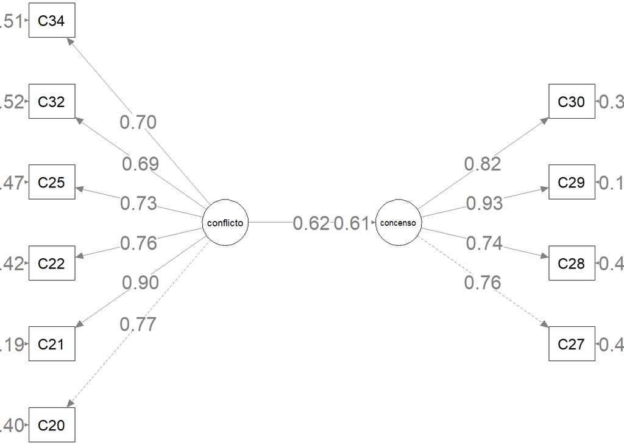

```r
# #Grafico para solo ver las Cargas

semPaths(fit6, what = "path", whatLabels = "std", style = "lisrel", rotation = 2, layout = "tree2", mar = c(1, 2, 1, 2), nCharNodes = 10, shapeMan = "rectangle", sizeMan = 8, sizeMan2 = 6, edge.label.cex=1.5, residuals = TRUE)
```